# Current-Voltage(I-V) Features of Photovoltaic Modules

Jiqi Liu, Alan Curran, Justin S. Fada, Xuan Ma, Wei-Heng Huang, Jennifer L. Braid, Roger H. French

2026-02-24

## Data Description

The dataset consists of current-voltage($I-V$) features obtained by $I-V$ feature extraction from $I-V$ curves of photovoltaic (PV) modules. The features have been extracted using the ddiv package algorithm for brand A PV modules under damp heat indoor accelerated exposures for up to 3000 hours. The I-V curves were measured in a step-wise manner after every 500h of exposure time, and provided by the SunEdison company. The I-V features include max power ($P_{mp}$), short circuit current ($I_{sc}$), current at max power ($I_{mp}$), fill factor ($FF$), series resistance ($R_s$), shunt resistance ($R_{sh}$), open circuit voltage($V_{oc}$), voltage at max power ($V_{mp}$). $R_{sh}$ is too noisy to contain for modeling. After checking the correlation between $I_{sc}$, $I_{mp}$, $V_{oc}$, $V_{mp}$, $FF$, $R_s$, we find that $FF$, $R_s$, $V_{mp}$ are highly correlated, and therefore only choose one of these three variables to be included in the model. Here we choose $I_{sc}$, $I_{mp}$, $R_s$ and $V_{oc}$ to be contained in the model and these four I-V features show no indication of high correlation. The trend of the I-V features are related with the mechanisms of PV degradation. The variable ‘$dy$’ is time that has been converted into decimal years so that $dy$=1 corresponds to 1 year of exposure time. We use this dataset to build an <S|M|R> network model with time ($dy$) as the exogenous stressor variable, four I-V features ($I_{sc}$, $I_{mp}$, $R_s$ and $V_{oc}$) as mechanistic endogenous variables and maximum power ($P_{mp}$) as the endogenous response variable.

## Load data and run code to build netSEM

```r
## Load the acrylic data set
data("IVfeature")

## Run netSEMp1 model
ans1 <- netSEMp1(IVfeature, exogenous = "dy", endogenous = "Pmp")
## Plot the network model for principle 1
plot(ans1, cutoff = c(0.25, 0.5, 0.8))

## Run netSEMp2 model
ans2 <- netSEMp2(IVfeature, exogenous = "dy", endogenous = "Pmp")
## Plot the network model for principle 2
plot(ans2, cutoff = c(0.25, 0.5, 0.8))
```

## Network diagram for data

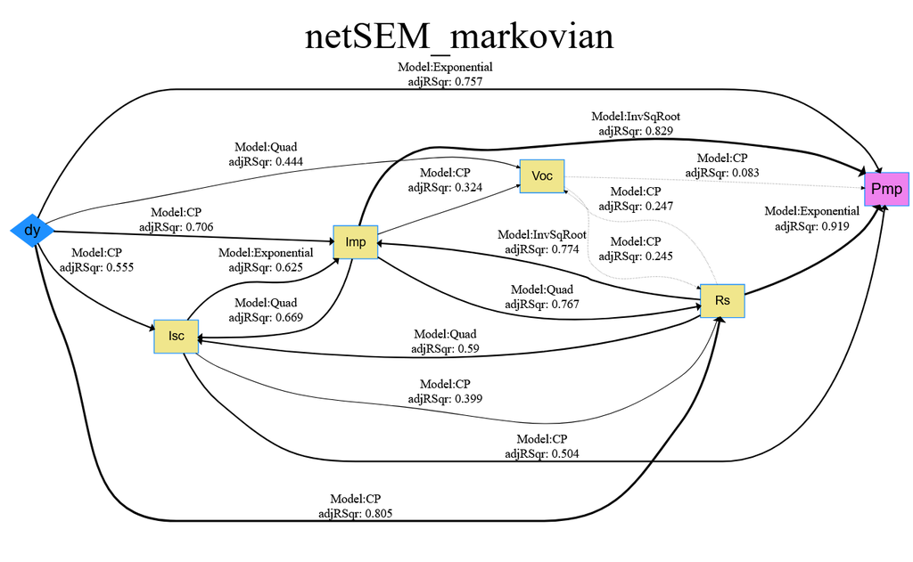

IVfeature netSEMp1 model

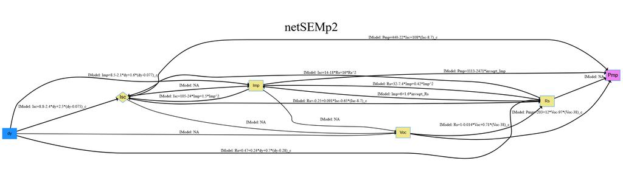

IVfeature netSEMp2 model

## Reference

1. ddiv: Data Driven I-v Feature Extraction, R package, https://CRAN.R-project.org/package=ddiv.
2. J. Liu, Alan Curren, Justin S. Fada, Xuan Ma, Wei-Heng Huang, C.Birk Jones, E. Schnabel, M. Kohl, Jennifer L. Braid, and Roger H.French, “Cross-correlation Analysis of the Indoor Accelerated and Real World Exposed Photovoltaic Systems Across Multiple Climate Zones,” in IEEE WCPEC-7 Conference, HI, 2018. DOI: https://doi.org/10.1109/PVSC.2018.8547840

## Acknowledgment

This material is based upon work supported by the U.S. Department of Energy’s Office of Energy Efficiency and Renewable Energy (EERE) under Solar Energy Technologies Office (SETO) Agreement Number DE-EE0007140.